### An Exploration of Race, Resources, and Income

### Data

home_ownership: Homeownership rate (2006-2010). white_not_hispanic: Percent of population that is white and not Hispanic (2010). black: Percent of population that is black (2010). pop2010: 2010 county population.

drugdeathrate_est_per_100000: Age-adjusted estimated rate of death from drug poisoning, including both illicit and prescription drugs, per 100,000 U.S. standard population for 2000.(2017 estimate). dist_MAT: Average Geographical Distance to Nearest Substance Abuse Facility providing medication assisted treatment (MAT) (2017).

bachelors: Percent of population that earned a bachelor’s degree (2006-2010). per_capita_income: Per capita money income in past 12 months (2010 dollars, 2006-2010).

### Research questions

1. Is there a negative relationship between 2010 county population and home ownership rate? Does this relationship change when considering the percentage of black county residents and home ownership rate?

We feel that the relationship between population and home ownership rate is worth studying because as the world’s population continues to increase, owning a home will continue to solidify as an option only for privileged individuals. As the counties’ population increases, we expect to observe a decrease in the home ownership rate because they are likely to have more urban areas, with less homeowners. Furthermore, we believe that we will discover that counties with a higher percentage of white residents will have a higher rate of homeownership. As evidenced by the New York Times article, “The Neighborhood is Mostly Black. The Home Buyers are Mostly White,” rising housing costs mean more affluent individuals are buying the houses, leaving many African-Americans without homes.

2. Is there a positive traceable association between estimated rate of death from drug poisoning per 100,000 in 2000 versus the average geographical distance to nearest substance abuse facility? Does the estimated rate of death from drug poisoning per 100,000 U.S. standard population for the year 2000 increase as the average geographical distance to the nearest substance abuse facility providing medication assisted treatment increases?

We feel that the relationship between the rate of death from drug poisoning and average distance to the nearest substance abuse facility is important to study because health care facilities are difficult to access in rural areas, especially in the United States. Tragically, this is where many drug related deaths occur. Therefore, we expect the data to show that as the average geographical distance to the nearest substance abuse facility increases, the estimated rate of death from drug poisoning per 100,000 residents for the year 2000 will increase as well. As written in an article in the British Medical Journal (BMJ), many studies have been conducted that observe a “distance decay association,” where there exists an association between “patients living closer to the healthcare facility and having better health outcomes… compared to those living further away.”

3. Is there a relationship between per capita income for county residents and percent of population that earned a bachelor’s degree?

We believe that the relationship between a bachelor’s degree and income is very relevant to us, all current college students. As it can cost hundreds of thousands of dollars to earn a bachelor’s degree, it is important for students and their families to know whether their investment will help them in the years to come. In the article entitled, “How does a college degree improve graduates’ employment and earnings potential,” the authors examine the large collection of evidence that point to the same conclusion: earning a college degree significantly improves an individual’s income. According to the article, possessors of a bachelor’s degree are much less likely to be unemployed and, on average, make around $1 million dollars throughout their lifetime than their peers who possess a high school degree. Therefore, we expect that as the percent of a county’s population that has earned a bachelor’s degree increases, the per capita income of county residents will increase as well. * * *

### Resources

Question 1: Badger, Emily, et al. “The Neighborhood Is Mostly Black. The Home Buyers Are Mostly  
White.” The New York Times, The New York Times, 27 Apr. 2019, www.nytimes.com/interactive/2019/04/27/upshot/diversity-housing-maps-raleigh-gentrification.html.

Question 2: Kelly, Charlotte et al. “Are differences in travel time or distance to healthcare for adults in global north countries associated with an impact on health outcomes? A systematic review.” BMJ open vol. 6,11 e013059. 24 Nov. 2016, doi:10.1136/bmjopen-2016-013059

Question 3: Edelson, David. “How Does a College Degree Improve Graduates’ Employment and Earnings Potential?” Association of Public & Land-Grant Universities, 27 Feb. 2020, www.aplu.org/projects-and-initiatives/college-costs-tuition-and-financial-aid/publicuvalues/employment-earnings.html.

### Exploratory data analysis

1. Is there a negative relationship between 2010 county population and home ownership rate? Does this relationship change when considering the percentage of black county residents and home ownership rate?

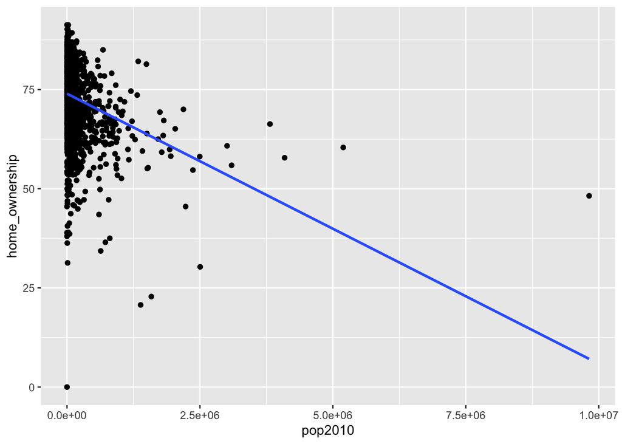

```r
ggplot(data = us_health, aes(x = pop2010, y = home_ownership)) + geom_point() +
  geom_smooth(method = "lm", se = FALSE)
```

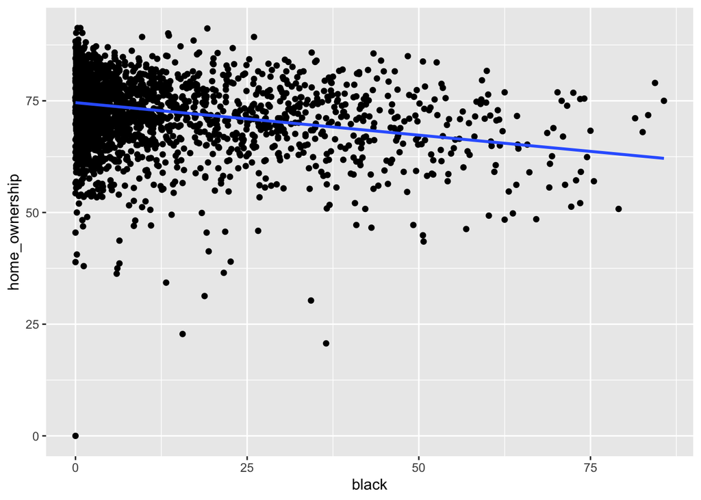

```r
ggplot(data = us_health, aes(x = black, y = home_ownership)) + geom_point() +
  geom_smooth(method = "lm", se = FALSE)
```

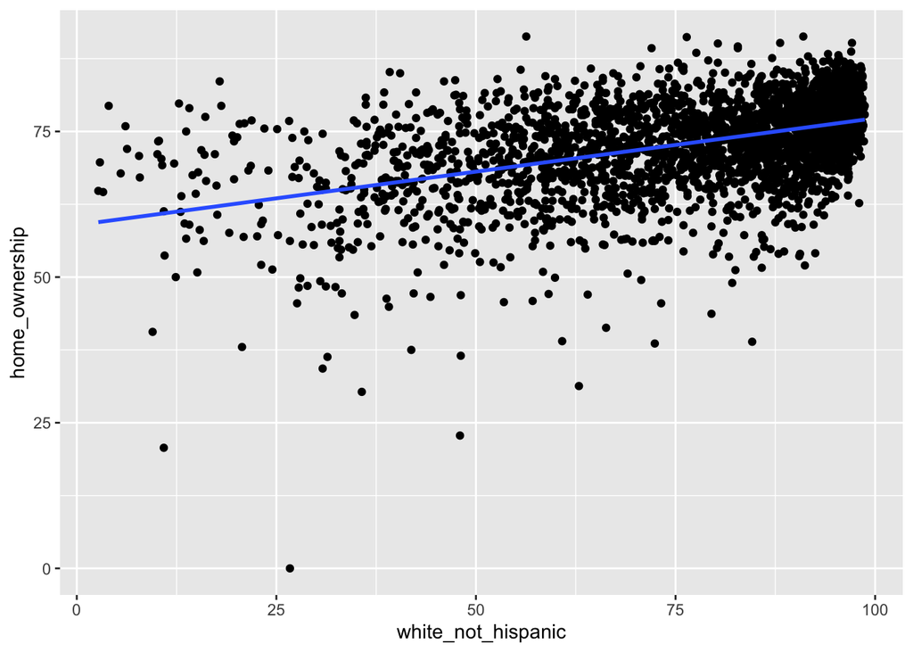

```r
ggplot(data = us_health, aes(x = white_not_hispanic, y = home_ownership)) + geom_point() +
  geom_smooth(method = "lm", se = FALSE)
```

[figure not shown]

```r
us_health = us_health %>% mutate(ethnicity = ifelse(white_not_hispanic > 50, "white-majority", "white-minority"))

ggplot(data = us_health, aes(x = pop2010, y = home_ownership)) +
  geom_point() +
  xlab("Ethnicity Percentage per County") +
  ylab("Home Ownership Rates") +
  ggtitle("Relation between Home Ownership Rates and County Ethnicity Percentages") + facet_grid(~ethnicity) + geom_smooth(method = "lm", se = FALSE)
```

```r
us_health %>% summarise(min_ownership = min(home_ownership), max_ownership = max(home_ownership), median_ownership = median(home_ownership))
```

```
##   min_ownership max_ownership median_ownership
## 1             0          91.3             74.6
```

2. Is there a relationship between estimated rate of death from drug poisoning per 100,000 U.S. standard population for 2000 and the average geographical distance to the nearest substance abuse facility providing medication assisted treatment?

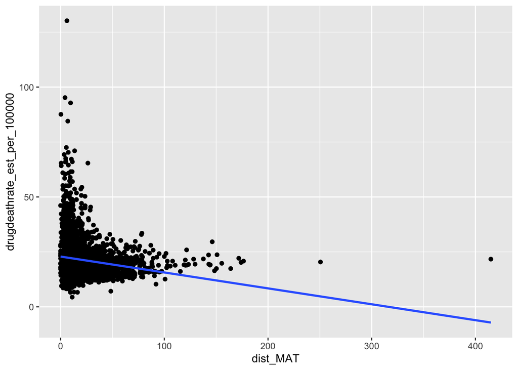

```r
ggplot(data = us_health, aes(y = drugdeathrate_est_per_100000, x = dist_MAT)) + geom_point() +
  geom_smooth(method = "lm", se = FALSE)
```

According to the geom plot we have created, as the geographical distance to the nearest substance abuse facility increases, the estimated rate of death from drug poisoning per 100,000 U.S. standard population for the year 2000 decreases. This indicates a negative association. This was not at all what we expected. We hypothesized that easy access to a substance abuse facility would lead to a lowered probability of death to drug poisoning. This was not the case.

3. Is there a relationship between per capita income for county residents and percent of population that earned a bachelor’s degree?

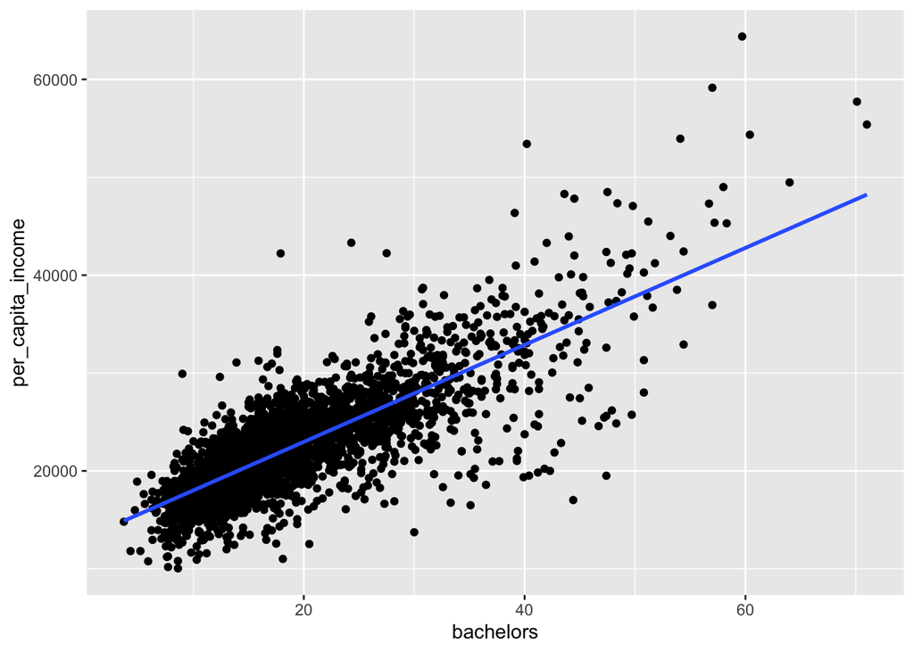

```r
ggplot(data = us_health, aes(y = per_capita_income, x = bachelors)) + geom_point() +
  geom_smooth(method = "lm", se = FALSE)
```

```r
us_health %>% summarise(min_income = min(per_capita_income), max_income = max(per_capita_income), median_income = median(per_capita_income), mean_income = mean(per_capita_income))
```

```
##   min_income max_income median_income mean_income
## 1      10043      64381         21773    22497.65
```

According to the graph we created as the number of county residents with bachelor’s increases so too does the amount of per capita income for county residents. Thus a strong association is apparent, this was indeed what we expected to discover upon conducting the test. From the summary statistics, the data is right-skewed, with the percentage of bachelors per county being clustered around 20% and per capita income being clustered around $22,000.

### Timeline, Teamwork, and Office hours

[Omitted for example, as this was for a semester-long course.]